# Untitled

# Active Power vs Time of Day

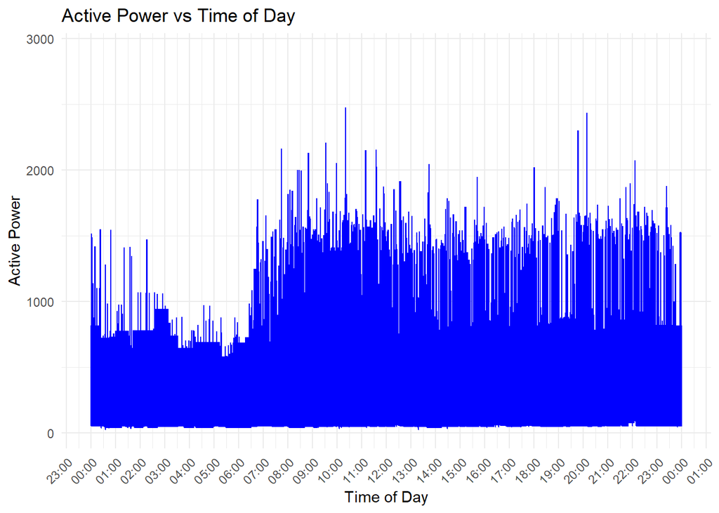

```r
# Subset the active power and datetime columns
energy <- energy %>% select(datetime, active_power)

# Ensure datetime is in POSIXct format
energy$datetime <- as.POSIXct(energy$datetime)

# Extract time of day
energy <- energy %>%
  mutate(time_of_day = format(datetime, "%H:%M:%S"))

# Plot active_power vs time_of_day
ggplot(energy, aes(x = as.POSIXct(time_of_day, format = "%H:%M:%S"), y = active_power)) +
  geom_line(color = 'blue') +
  scale_x_datetime(date_labels = "%H:%M", date_breaks = "1 hour") +
  ggtitle("Active Power vs Time of Day") +
  xlab("Time of Day") + ylab("Active Power") +
  theme_minimal() +
  theme(axis.text.x = element_text(angle = 45, hjust = 1))
```

The illustration depicts a 24-hour cycle of active power utilization, displaying a daily pattern characterized by fluctuations in energy consumption levels, alternating between low and high. During the night period (00:00 - 06:00), there is a consistent presence of low and stable active power, denoting a decrease in energy consumption while individuals are asleep. In the morning hours (06:00 - 12:00), there is a discernible rise in active power, peaking typically between 10:00 and 12:00, indicating heightened energy usage attributed to morning-related tasks. The afternoon period (12:00 - 18:00) maintains elevated levels of active power with notable fluctuations, signaling sustained high energy usage. By evening (18:00 - 23:00), there is a second peak in active power, succeeded by a gradual decrease towards midnight, reflecting a probable increase in energy consumption as individuals engage in evening activities before retiring to bed.

# Distribution of active power after removing outliers

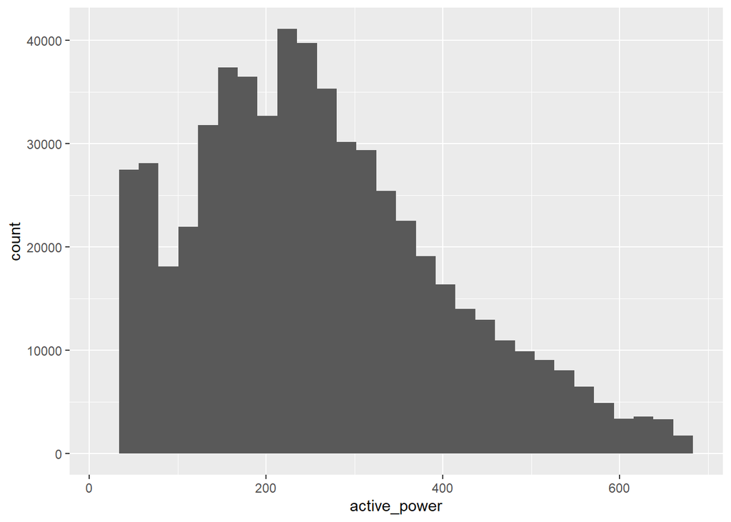

```r
ggplot(data = energy_capped, aes(x=active_power)) + geom_histogram(bins = 30)
```

```r
summary(energy_capped$active_power)
```

```
##    Min. 1st Qu.  Median    Mean 3rd Qu.    Max.    NA's
##    24.4   156.8   243.7   262.1   348.2   673.8   23398
```